# Homework3

2025-09-25

# Should We Change the Design?

I would recommend that this company commit to redesigning their website.

```r
# load in data
data <- read.csv("homework3_data.csv")
```

# Supporting Evidence

### Getting the color palette from Target

```r
library(colorfindr)
# Target color palette
dat <- get_colors("OtherWebsite.png")
cols <- make_palette(dat[1:100, ])
```

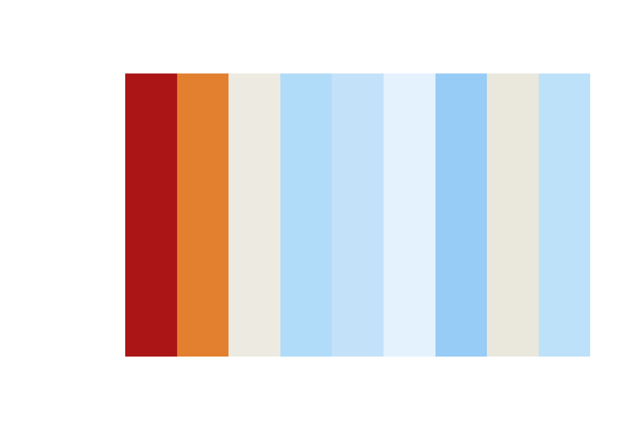

```r
cols
```

```
##  [1] "#FFFFFF" "#BB271A" "#E9933D" "#F1EFE7" "#BEE3FA" "#CDE8FB" "#E9F5FE"
##  [8] "#A5D6F7" "#EEECE4" "#C8E7FA"
```

## Part A (Supporting Evidence)

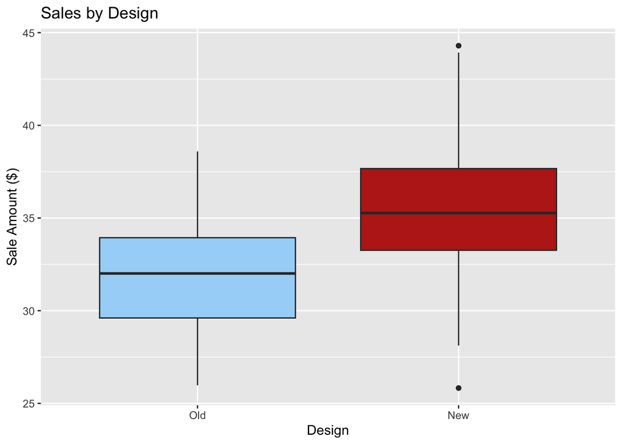

```r
library(dplyr)
library(ggplot2)

df <- data %>%
  mutate(design_f = factor(design, labels = c("Old", "New")))

# Target palette
pal_cat <- c("Old" = "#A5D6F7", "New" = "#BB271A")

# Boxplot to show mean differences between old and new
ggplot(df, aes(x = design_f, y = sales, fill = design_f)) +
  geom_boxplot() +
  scale_fill_manual(values = pal_cat, guide = "none") +
  labs(title = "Sales by Design",
       x = "Design", y = "Sale Amount ($)") +
  theme_grey()
```

As we can see the new design has a higher median sales amount than the old design, supporting that they should change their design.

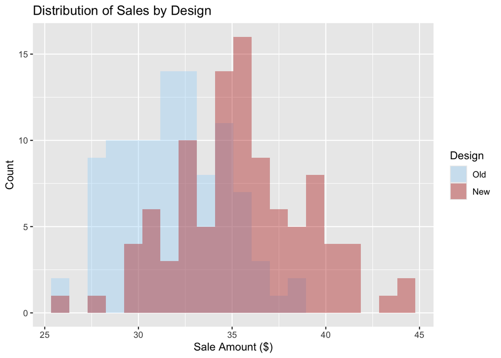

```r
# Distribution plot to show how the new design has shifted right
ggplot(df, aes(x = sales, fill = design_f)) +
  geom_histogram(alpha = .4, position = "identity", bins = 20) +
  scale_fill_manual(values = pal_cat, name = "Design") +
  labs(title = "Distribution of Sales by Design",
       x = "Sale Amount ($)", y = "Count")
```

This graph supports the premise because we can see that the new design distribution is shifted to the right meaning higher sales.

## Part B (Estimate the difference)

```r
# calc the mean diff between averages

mean_old = mean(df$sales[df$design_f == "Old"])
mean_new = mean(df$sales[df$design_f == "New"])
diff = mean_new - mean_old

c(mean_old = mean_old, mean_new = mean_new, diff = diff)
```

```
##  mean_old  mean_new      diff
## 31.848190 35.513095  3.664904
```

The average difference between the old and new design is $3.66 in favor of the new design.

## Part C (check $1.80)

```r
# Do a t test to show the difference is significant
t_test <- t.test(df$sales[df$design==1],
                    df$sales[df$design==0],
                    alternative = "greater",
                    mu = 1.8)

t_test
```

```
##
##  Welch Two Sample t-test
##
## data:  df$sales[df$design == 1] and df$sales[df$design == 0]
## t = 4.1499, df = 186.01, p-value = 2.528e-05
## alternative hypothesis: true difference in means is greater than 1.8
## 95 percent confidence interval:
##  2.922037      Inf
## sample estimates:
## mean of x mean of y
##  35.51309  31.84819
```

Null hypothesis (H₀): The mean increase in sales from the new design compared to the old design is less than or equal to $1.80. Alternative hypothesis (Hₐ): The mean increase in sales from the new design compared to the old design is greater than $1.80.

Since the p-value (2.53e-05) is less than 0.05, we reject the null hypothesis, providing strong evidence that switching to the new design leads to a significant increase in sales beyond the $1.80 threshold.

# Alternative Statement